# Estimating Total Gasoline Consumption of Miami University Commuters

Nick Baroun & Reece Fannon

11 October 2024

# 1 Introduction

This report provides an in-depth analysis and estimation of the gasoline consumption associated with commuting students and faculty at Miami University. The initiative aligns closely with the University’s Climate Action Plan and the broader directives outlined by President Crawford, emphasizing the importance of sustainability and carbon reduction efforts. Understanding and quantifying commuting emissions is crucial as it represents a significant component of Scope 3 emissions—those indirectly linked to university operations but essential for comprehensive climate reporting.

Accurate estimation of gas consumption poses certain challenges. The available data sources, including License Plate Recognition (LPR) parking data and an online permit application survey, offer limited but insightful inputs. Notably, the survey data—while incomplete—provides critical self-reported home addresses, allowing for Geographic Information System (GIS)-based mileage calculations. Individuals with commutes exceeding 45 miles one way (90-mile round trip) were excluded to focus on realistic, frequently traveled routes.

The primary goal of this study is twofold:

1. Mileage Estimation: Calculate the total weekly and annual commuting mileage for students and employees.
2. Fuel Consumption Estimation: Estimate the corresponding weekly and annual gasoline usage for both groups, broken out separately for students and employees.

Given the inherent uncertainty in any estimation method, this report also explores how margins of error can be applied to refine the results. Through this work, the university can better assess the environmental impact of commuter behavior and identify potential opportunities for sustainable transportation strategies. The outcomes will contribute toward advancing the university’s climate objectives by establishing baseline data for future initiatives aimed at reducing carbon emissions.

# 2 Data

This section provides a detailed overview of the two data sets provided for the analysis: the **employee commuting data** and the **student commuting data**. These data sets serve as the foundation for estimating the total mileage and gasoline consumption of commuting students and faculty at Miami University. Below is a summary of the key fields and information contained in each data set. The list of features provided are as follows:

- **`DESIGNATION`**: Differentiates between faculty and staff.
- **`live_on_campus_2021_2022`**: A boolean of whether or not the student lived on or off campus in the 2021/2022 academic year.
- **`commute_days_fall_spring`**: Number of commuting days during the fall and spring semesters.
- **`remote_days_fall_spring`**: Days employees worked remotely during these semesters.
- **`commute_days_summer_jterm`**: Number of commuting days during summer and J-term periods.
- **`commute_gaspowered_100pct_of_time`**: Indicates whether employees exclusively used gas-powered vehicles.
- **`drive_gas` / `drive_electric`**: Percentage of commute done using gas or electric vehicles.
- **`walk` / `bicycle` / `carpool_as_passenger` / `drive_motorcycle`**: Other modes of transportation employees may have used.
- **`BCRTAbus`**: Utilization of regional transit (Butler County Regional Transit Authority).
- **`daily_miles_one_way`**: One-way commute distance in miles, calculated through GIS analysis.
- **`live_on_campus_in_2021_2022`**: Specifies whether the student resided on campus during the 2021–2022 academic year.

For the student data set (`student_miles`), the `live_on_campus_in_2021_2022` and `other` columns are removed to focus on relevant information. The `walk` column is then relocated to appear before the `bicycle` column for better organization, and any missing values in the student data set are replaced with zeros to ensure data consistency.

In processing the employee data set (`employ_miles`), the 1971st row is removed, which had an NA value for `commute_gaspowered_100pct_of_time`. Records with missing values in the `commute_gaspowered_100pct_of_time` field are filtered out to maintain data integrity. For entries where `commute_gaspowered_100pct_of_time` is “Yes,” the `drive_gas` value is set to 100, indicating full reliance on gas-powered commuting. The designation “Employee” is assigned to all entries, and commute days are standardized by setting both `commute_days_summer` and `commute_days_jterm` to the value of `commute_days_summer_jterm`.

The `daily_one_way_miles` are given in straight line, Euclidean distances from their address to Upham Hall. However, this distance ignores the real driving distance that commuters must travel, as it si almost never possible to travel a straight path to a destination. The works of (Gonçalves et al. 2014) and (Boscoe, Henry, and Zdeb 2012) compare the difference between the Euclidean distance and real traversible driving distances, and use regression models to estimate a multiplicitive scaling factor to convert Euclidean to driving distance. They find scaling factors of $1.345$, $1.445$ and $1.417$ respectively. The authors additionally note that these factors are eerily similar to the factor $\sqrt{2}$, as this is the ratio of the lengths between the lengths of the non-hypotenuse sides (a & b) together over the hypotenuse. As such, we decide to convert the Euclidean one-way trip in miles to the Manhattan Distance, where we multiply by a scalar of $\sqrt{2}$.

Unnecessary columns are removed. The remaining columns are rearranged and any missing values in the employee data set are also filled with zeros.

After cleaning both data sets, they are combined into a single data frame. The `DESIGNATION` column is standardized by trimming any whitespace and converting the text to title case, then set as a factor with levels “Student” and “Employee” to facilitate categorical analysis. Column names are renamed to more descriptive and lowercase titles for clarity.

To prepare the data for analysis, the total transportation usage is calculated by summing specific transportation mode columns. Each transportation mode’s value is then normalized by converting them into percentages of the total, ensuring that the data reflects the proportionate use of each mode. Finally, the processed and combined data set is exported to a new CSV file named `employee_student_90miles_no_address.csv`, making it ready for further analysis or reporting.

These data sets will be used to estimate total weekly and annual commuting mileage, along with the corresponding gasoline consumption for both students and employees.

# 3 Exploratory Data Analysis

Figure 3.1 shows for the proportion that each mode of transportation makes up of a listed proportion of the of travel time. For Employees that listed a mode of transportation used 0% of the time: bike, bus, carpool, electric, motorcycle, and walking share about equal amounts of this proportion; gas is not present. Going to the other extreme end for the employees, almost all employees who listed any mode of transportation as taking up 90-100% of their commute time traveled by gasoline vehicle. This is similar to the proportions among students as well.

Figure 3.2 shows how distances are distributed across certain proportions doing a mode of transportation. Focusing on the gas category, people that said they traveled by gasoline vehicle 90%-100% of the time had a median distance just over 10 miles away, while people who said they traveled by gasoline vehicle 0% had a median one-way distance of close to a single mile. Jumping to the motorcycle category, those who rode motorcycles to campus did so at most 10% of the time, commuting for a median one-way distance about 33 miles. Moving to the walk category, those that walked to campus 90%-100% of the time had some of the smallest median one-way distance.

Figure 3.3 shows each mode of transportation, and for each bin of proportions doing traveling via that mode, we rank them based on their median distance from campus, hoping to capture some correlation between proclivity towards a mode of transportation and how far of a commute someone has. Consider the row “walk”, those who walked 0% of the time had the greatest one-way distance to campus, where as the respondents who listed “walk” as taking up 60%-70% of their commute had on average the least amount of distance to travel. Notice how the “walk” and “gas” rows are inverted. For the gas row, it is shown that those who drove a gas-vehicle 90%-100% of the time had, on average, was the furthest away from campus.

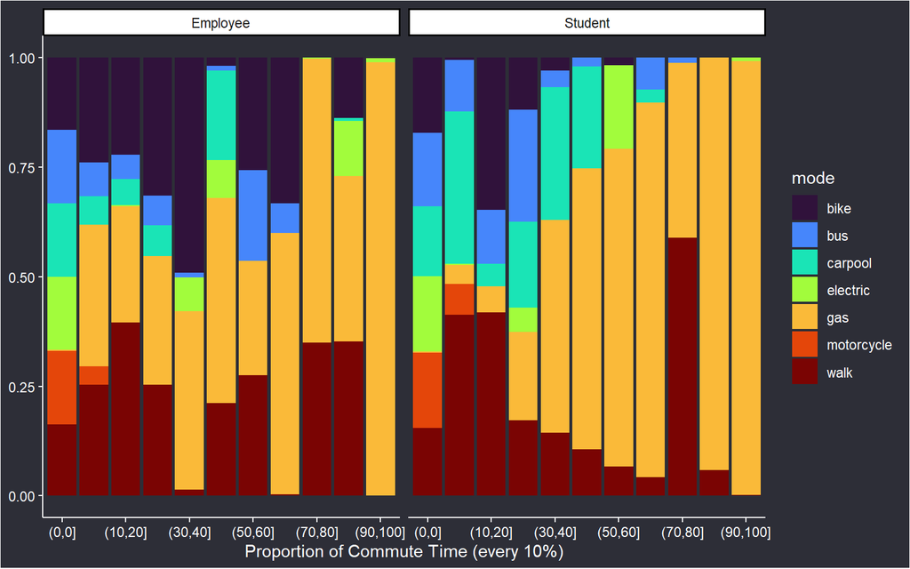

Figure 3.1: Proportion of Commute Time Via a Mode of Transportation

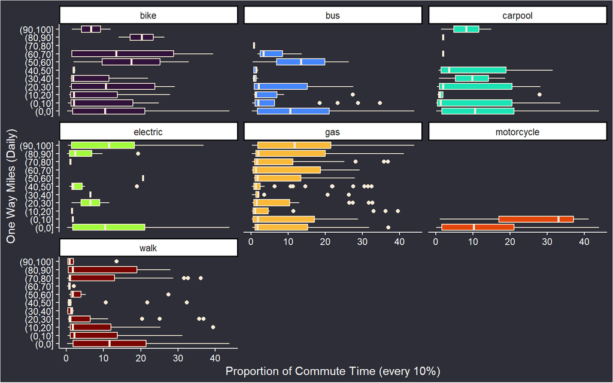

Figure 3.2: Distribution of Daily One-way Miles Travelled by each Mode of Transportation

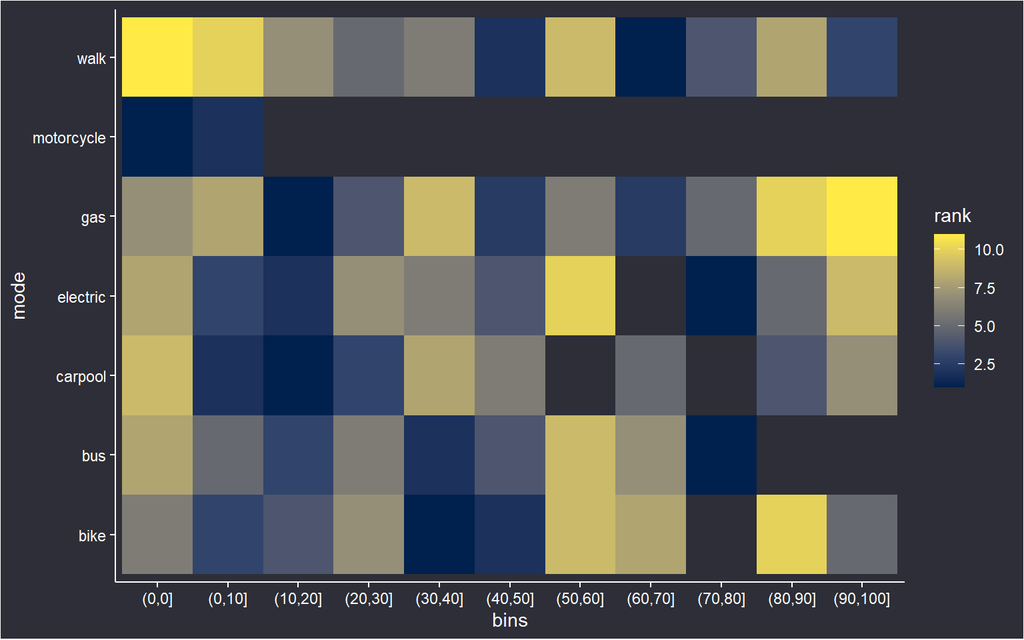

Figure 3.3: Median Distance from Campus by Proportion in Mode of Transportation

Table 3.1 displays counts of people that fall into these categories, most people do in fact drive by gasoline vehicle from 90%-100% of the time. Only 20 people drive an electric car 90%-100% of their commute.

Table 3.2 gives a summary of the distances from campus employees and students. The data set consists mostly of employees (N = 1964). The average one-way miles for the employees (12.25) was greater than that of the average for students 11.56, and varied less slightly than the students (Employee Standard Deviation: 11.21, Student Standard Deviation: 11.57). Both distributions had medians less than the mean, suggesting both were skewed-right, as seen in figure 3.4. Both distributions of One-way distance are skewed right, where the plurality of observations have less than 2.5 miles of a one-way trip. Ignoring the students that live in oxford, the rest of the student distribution does seem to be more symmetric.

Figure 3.5 shows the distribution of the average weekly days traveling to and from campus, for both students and employees. Both distributions for weekly commute days skew to the left, where for both students and faculty the most frequent observation is 5 days out of the week. No employees commutate all 7 days of the week. The second highest amount of days student commute to campus 7.

Table 3.1:

| Counts of Individuals by Mode of Transportation Proportion Of Commute Time | Counts of Individuals by Mode of Transportation Bike | Counts of Individuals by Mode of Transportation Bus | Counts of Individuals by Mode of Transportation Carpool | Counts of Individuals by Mode of Transportation Electric | Counts of Individuals by Mode of Transportation Gas | Counts of Individuals by Mode of Transportation Motorcycle | Counts of Individuals by Mode of Transportation Walk |
| --- | --- | --- | --- | --- | --- | --- | --- |
| (0,0] | 2212 | 2237 | 2226 | 2243 | 46 | 2280 | 2078 |
| (0,10] | 23 | 17 | 28 | 1 | 32 | 3 | 54 |
| (10,20] | 17 | 6 | 7 | 1 | 18 | 0 | 36 |
| (20,30] | 12 | 9 | 7 | 2 | 22 | 0 | 19 |
| (30,40] | 6 | 3 | 2 | 1 | 13 | 0 | 9 |
| (40,50] | 3 | 5 | 9 | 6 | 45 | 0 | 30 |
| (50,60] | 2 | 2 | 0 | 1 | 15 | 0 | 8 |
| (60,70] | 4 | 3 | 1 | 0 | 24 | 0 | 4 |
| (70,80] | 0 | 1 | 0 | 1 | 38 | 0 | 21 |
| (80,90] | 2 | 0 | 1 | 7 | 42 | 0 | 13 |
| (90,100] | 2 | 0 | 2 | 20 | 1988 | 0 | 11 |

Table 3.2:

| designation | One-Way Daily Miles traveled to reach Oxford Campus Mean | One-Way Daily Miles traveled to reach Oxford Campus Std.Dev | One-Way Daily Miles traveled to reach Oxford Campus Min | One-Way Daily Miles traveled to reach Oxford Campus Q1 | One-Way Daily Miles traveled to reach Oxford Campus Median | One-Way Daily Miles traveled to reach Oxford Campus Q3 | One-Way Daily Miles traveled to reach Oxford Campus Max |
| --- | --- | --- | --- | --- | --- | --- | --- |
| Employee | 12.256 | 11.210 | 0.204 | 1.772 | 10.302 | 21.185 | 43.908 |
| Student | 11.566 | 11.574 | 0.180 | 0.840 | 9.596 | 20.460 | 41.180 |

Table 3.3:

| designation | Days per Week Commuting to Oxford Campus 0 | Days per Week Commuting to Oxford Campus 1 | Days per Week Commuting to Oxford Campus 2 | Days per Week Commuting to Oxford Campus 3 | Days per Week Commuting to Oxford Campus 4 | Days per Week Commuting to Oxford Campus 5 | Days per Week Commuting to Oxford Campus 6 | Days per Week Commuting to Oxford Campus 7 |
| --- | --- | --- | --- | --- | --- | --- | --- | --- |
| Employee | 53 | 31 | 99 | 318 | 272 | 1191 | 0 | 0 |
| Student | 4 | 2 | 7 | 12 | 46 | 163 | 37 | 48 |

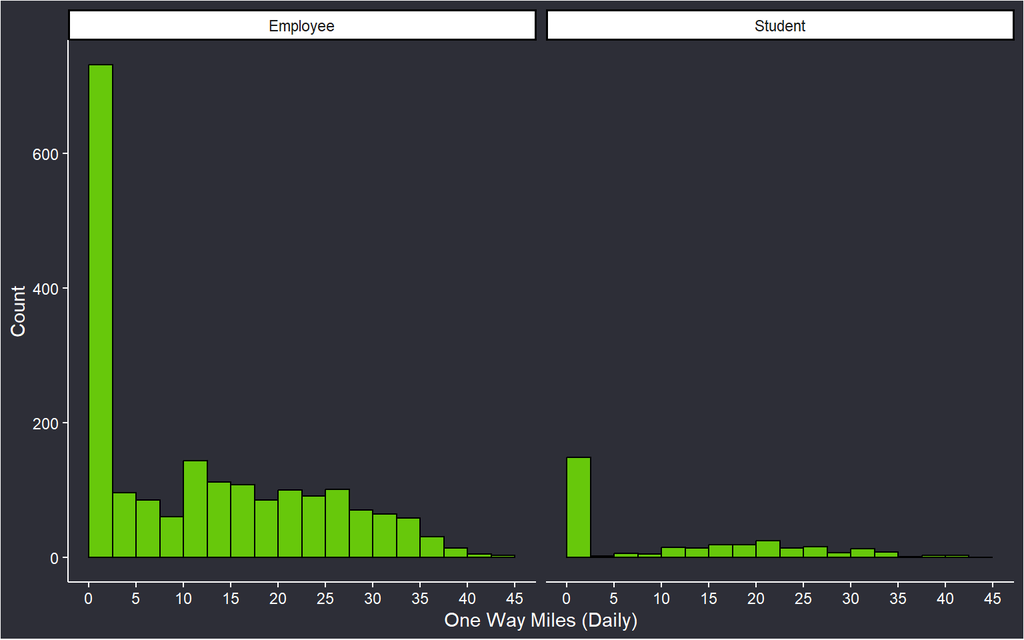

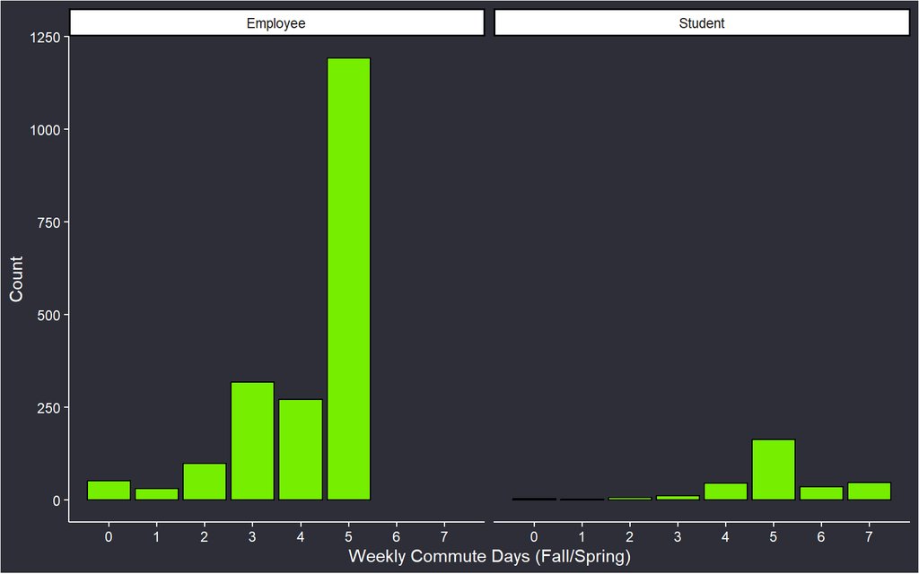

# 4 Methods

## 4.1 Assumptions

In order to generate reliable and implementable estimates for gas consumption, several assumptions are required due to the variability in survey responses and the inherent uncertainties in the data. These assumptions err on the side of overestimating gas consumption to ensure that Miami University can confidently meet its sustainability targets. Below is a detailed overview of the key assumptions and their justifications.

**Assumption 1**

*Participants listing walking or biking as a mode of transportation do so only within a 1.5-mile radius of the Oxford campus.*

**Justification:**  
Given that participants in the survey were seeking parking permits, it is reasonable to assume that their primary mode of transport involves a vehicle. Walking or biking likely only occurs within short distances on campus, such as between parking lots and academic buildings. The farthest lot (Chestnut Fields) is 0.86 miles from the main academic area (Upham Hall), supporting the 1.5-mile assumption. This conservative estimate ensures that walking and biking are appropriately accounted for without significantly under reporting gasoline consumption.

**Assumption 2**

*For participants living beyond the 1.5-mile radius who report walking or biking, we assume they primarily commute by vehicle and only walk or bike from a campus parking lot to their final destination.*

**Justification:**  
Some survey respondents listed extensive use of walking or biking, even with home addresses located as far as 30 miles from campus. It is implausible that these individuals walk or bike such long distances daily. A more reasonable interpretation is that they drive to campus, park, and walk or bike short distances to their destinations. For consistency and overestimation purposes, we assume they walk or bike up to half a mile after parking. This aligns with typical parking patterns and ensures that vehicle use is not underestimated.

**Assumption 3**

*Mileage calculations use the worst fuel economy figures: 28 mpg for gasoline vehicles, 98 MPGe for electric vehicles, and 42.3 mpg for motorcycles.*

**Assumption 4**

*Mileage associated with BCRTA buses will not be included in this analysis.*

**Justification:**  
BCRTA buses operate on fixed schedules and routes, making their mileage and fuel consumption straightforward to track independently. Excluding these miles from the current analysis focuses attention on personal commuting behaviors, which are the primary target for this report. University officials can easily obtain precise bus mileage and emissions data separately for more targeted emissions reduction efforts.

**Assumption 5**

*Carpool passengers contribute to gasoline consumption at a marginal rate of* $\frac{1}{49}$ of the vehicle’s fuel economy.

**Justification:**  
Research indicates that every additional 100 pounds of weight reduces fuel efficiency by approximately 1–2%. Assuming an average passenger weighs at least 100 pounds, the effect on fuel consumption is modeled using the formula $\frac{Dist}{MPG} - \frac{Dist}{.98MG} = \frac{\text{Dist}}{\text{MPG}} \left( \frac{-1}{49} \right)$. This factor reflects the marginal contribution of carpool passengers to total fuel consumption, ensuring that the effects of carpooling is not ignored in our analysis.

**Assumption 6**

*Vehicle fuel efficiency decreases in winter, with gasoline vehicles operating at 85% of their normal efficiency and electric vehicles at 60%.*

**Justification:**  
It is well-documented that cold weather adversely affects vehicle performance (U.S. Department of Energy, n.d.b). Gasoline vehicles experience about a 15% reduction in fuel economy, while electric vehicles see up to a 40% decrease. These adjustments account for seasonal variability in energy consumption, ensuring that the annual estimates reflect realistic fuel efficiency changes. This conservative approach further ensures that winter emissions are not underestimated, contributing to a robust overestimation framework.

These assumptions are designed to address data uncertainties and ensure that gas consumption estimates err on the side of caution. By making conservative assumptions, the analysis guarantees that Miami University can confidently meet its net-zero emissions goals, knowing that actual emissions will likely be lower than estimated. This careful approach provides a reliable framework for decision-making and sustainability planning.

## 4.2 Total Estimate Calculation

Adhering to the assumptions outlined, the following step-by-step procedure describes how we estimate total commuting distances and gasoline consumption for Miami University students and faculty. This approach ensures consistency, accuracy, and a conservative overestimation of fuel consumption to align with the university’s carbon reduction goals.

**Calculate Weekly Commute Distance by Term**

For each survey respondent, we calculate the total weekly miles traveled by multiplying their one-way commute distance by the average number of days they reported commuting for each term (Fall, Winter, Spring, and Summer). This gives a term-specific total distance traveled.

$$\text{Weekly Commute Distance} = \text{One-Way Distance} \times \text{Commute Days per Week}$$

**Estimate Distance Walked or Biked**

- **For Respondents within 1.5 Miles of Campus**:  
  We directly multiply their weekly total distance by the proportion they reported walking or biking.

  $$\text{Walk/Bike Distance} = \text{Weekly Total Distance} \times \text{Proportion Walk/Bike}$$
- **For Respondents Beyond 1.5 Miles**:  
  Since they are too far to realistically walk or bike the entire way, we assume they only walk or bike half a mile after parking on campus. This half-mile distance is multiplied by the reported proportion.

  $$\text{Adjusted Walk/Bike Distance} = 0.5 \, \text{miles} \times \text{Proportion Walk/Bike}$$

This step ensures that walking or biking is not overestimated for respondents living farther away from campus.

**Calculate Weekly Motorized Transportation Distance**

We subtract the estimated walk or bike distances from the total weekly commuting distance to isolate the portion of the commute that involves motorized transportation. Since the distances recorded are one-way, we multiply the remaining distances by 2 to account for round trips.

$$\text{Motorized Distance} = (\text{Weekly Total Distance} - \text{Walk/Bike Distance}) \times 2$$

**Rescale Proportions for Motor Modes of Transportation**

Since the distances walked or biked have been subtracted, we rescale the reported transportation mode proportions (e.g., driving gas-powered, electric, motorcycle, etc.) to apply only to the remaining motorized transportation distances. This ensures that the distance calculations align with the relevant modes contributing to carbon emissions.

**Annualize Commute Distances**

To estimate annual commute distances for each respondent, we account for the variation in the number of days traveled across different semesters. The number of travel days is determined by a weighted sum of regular full weeks, weeks with less than 5 school days, and finals week. We treat each week as having a weight of $\frac{7-\text{days off}}{7}$ such that full weeks have a weight of $\frac{7}{7} = 1$ and any week with fewer school days will have lower weights. We assume that weekends don’t matter because days off don’t impact someone’s decision of traveling to campus on Saturday or Sunday. This weighted average is not an integer, so we take the ceiling of this number to get an estimate for the number of days some travels across an entire semester, and the ceiling is preferred to rounding so as to be biased towards overestimation.

$$\text{Total Travel Days} = \text{Weekly Average Travel Days}*\left\lceil \sum_{\text{weeks}} \left(\frac{7 - \text{Days Off}}{7}\right) + \frac{5}{7} \, \text{(Finals Week)} \right\rceil$$

We compute this for each term, and the sum of the number of days a respondent travels across each semester gives the net annual number of days they travel. These estimated travel days are multiplied by the weekly motorized commute distances to obtain annual travel distances.

**Estimate Gasoline Consumption by Mode of Transportation**

For each mode of transportation, we calculate the distance traveled annually and estimate the corresponding fuel consumption.

$$\text{Gallons of Gas} = \frac{\text{Distance by Mode}}{\text{MPG}}$$

- **Winter Adjustments**: We reduce fuel efficiency during the winter term according to the assumptions:
  - Gasoline vehicles: 85% efficiency
  - Electric vehicles: 60% efficiency

**Estimate Population Totals and Confidence Intervals**

Using the individual respondent data, we generate point estimates and confidence intervals for the population totals. To estimate a population total, we actually estimate the population mean first, then multiply this quantity by the population size. The reason for this is because the $\sum_{i=1}^n Y_i$ from the sample observations will of course by magnitudes smaller than the $\sum_{i=1}^N Y_i$ from the population because we are summing together less terms. But we can say that the sample mean $\bar{Y}_n$ will be reflective of the population mean $\bar{Y}_N$. So if $\bar{Y}_n \approx \bar{Y}_N$ then we simply multiply by $N$ to get an estimate for the total.

We can then get the total estimate as follows:

$$\begin{aligned}
\text{95% Confidence Interval} &\approx \bar{X} \pm 1.96\sqrt{\frac{\sigma^2}{n}} \\
\text{95% Confidence Interval for Total} &\approx N\bar{X} \pm 1.96\sqrt{N^2\frac{\sigma^2}{n}} \\
&= N\Big(\bar{X} \pm 1.96\sqrt{\frac{\sigma^2}{n}}\Big)
\end{aligned}$$

In the context of our analysis, the **finite population correction (FPC)** is crucial for accurately estimating the variability of our sample-based results when extrapolating to the entire population. The formula $(1 - \frac{n}{N})$ adjusts the standard error to account for the fact that we are working with a relatively small, well-defined population—specifically, the commuting students and faculty at Miami University—rather than an infinite or very large population. Without this correction, the confidence intervals may be unnecessarily wide, leading to less precise estimates. As the sample size $n$ becomes a larger proportion of the total population $N$, the variability of the sample decreases, and the FPC appropriately reduces the standard error, yielding narrower and more accurate confidence intervals. This adjustment ensures that our estimates of total mileage and gas consumption reflect the true characteristics of the population, providing Miami University with higher confidence in the precision of the reported results.

$$\approx N\Big(\bar{X} \pm 1.96\sqrt{\Big(1-\frac{n}{N}\Big)\frac{\sigma^2}{n}} \ \Big) \ , \\
\text{Where } n \text{ and } N \text{ are sample size and population size, respectfully.}$$

The above formulation is sufficient for weekly and annual totals for students and employees separately. For the combined totals, it is not sufficient to just add the totals for each for students and employees. Observe that

$$\begin{aligned}
Y_T = \sum_{i = 1}^{N}Y_i = \sum_{s = 1}^{n_S}Y_s + \sum_{e = 1}^{n_E}Y_e & \iff \frac{1}{N}\sum_{i = 1}^{N}Y_i = \frac{1}{N}\sum_{s = 1}^{n_S}Y_s + \frac{1}{N}\sum_{e = 1}^{n_E}Y_e < \bar{Y}_S + \bar{Y}_E\\
& \iff \bar{Y}_T < \bar{Y}_S + \bar{Y}_E\\
\end{aligned}$$

So we tend to underestimate the mean, which will then cause an underestimation of the total. This is because we ignore the individual population sizes when we assign the weights to the weighted average. We don’t want to give the same weight of $\frac{1}{N}$ to both populations, because their individual population means will have their respective weights. We can get an exact equivalence via the following:

$$Y_T = \sum_{i = 1}^{N}Y_i = \sum_{s = 1}^{n_S}Y_s + \sum_{e = 1}^{n_E}Y_e = n_S\bar{Y}_S + n_E\bar{Y}_E \iff \bar{Y}_T = \frac{1}{N}( n_S\bar{Y}_S + n_E\bar{Y}_E) = \frac{n_S}{N}\bar{Y}_S + \frac{n_E}{N}\bar{Y}_E$$

Using this representation of $\bar{Y}_T$, we can then calculate a 95% confidence interval as

$$\begin{aligned}
\text{95% Confidence Interval} &\approx \bar{Y}_T \pm 1.96\sqrt{V(\bar{Y}_T)} \\
\text{95% Confidence Interval for Total} &\approx N\bar{Y}_T \pm 1.96\sqrt{V(N\bar{Y}_T)} \\
&\approx N(\frac{n_S}{N}\bar{Y}_S + \frac{n_E}{N}\bar{Y}_E) \pm 1.96\sqrt{V(N(\frac{n_S}{N}\bar{Y}_S + \frac{n_E}{N}\bar{Y}_E))} \\
& = (n_S\bar{Y}_S + n_E\bar{Y}_E) \pm 1.96\sqrt{V(n_S\bar{Y}_S + n_E\bar{Y}_E))}\\
& = (n_S\bar{Y}_S + n_E\bar{Y}_E) \pm 1.96\sqrt{n_SV(\bar{Y}_S) + n_EV(\bar{Y}_E))}\\
& = (n_S\bar{Y}_S + n_E\bar{Y}_E) \pm 1.96\sqrt{n_Ss_S^2 + n_Es_E^2}\\
\end{aligned}$$

where $n_S, \bar{Y}_S, s_S$ and $n_E, \bar{Y}_E, s_E$ are the population size, sample means and sample standard deviations for the students and employees, respectively, assuming that students and employees are independent.

## 4.3 Software

For our analysis, we will be utilizing the statistical software `R` (R Core Team 2024) to conduct all data processing, exploratory data analysis (EDA), model fitting and statistical tests. Specifically, we will employ several R packages to enhance our workflow and output. The `tidyverse` (Wickham et al. 2019) package will be used for data manipulation and visualization. We will also leverage `kableExtra` (Zhu 2024) for constructing tables. Finally, `knitr` (Xie 2024) will assist in generating and outputting the final HTML document.

# 5 Results

## 5.1 Estimating Total Distance Traveled

Table 5.1 shows the point estimates and corresponding confidence intervals for the total weekly distance traveled using carbon emitting modes of transportation for students and employees each semester. Table 5.2 shows the point estimates and corresponding confidence intervals for the total weekly distance traveled using carbon emitting modes of transportation for both students and employees combined each semester. Likewise, Table 5.3 and Table 5.4 show the total annual distance traveled by students and employees and for both combined, respectively. In general, employees travel further than students, and the Fall and Spring semesters constitute a higher proportion of the travel distance. Employees tend to travel fairly consistent amounts all year round, while students mostly commute only during Fall and Spring semesters. This makes sense, since full-time staff are likely working all year round, and some faculty members may be teaching or visiting their offices. The vast majority of the student body has no obligation to be on campus during Winter and Summer, and are rather enjoying their time off. As a whole, according to table 5.4, we estimate that the total distance traveled in the 2021-2022 fiscal year is about $34,329,519$ miles and 95% confident it is somewhere between $33.6$ million and $35$ million miles.

Table 5.1:

| Total Distance Traveled Weekly by Term and Designation (with 95% Bounds) Designation | Total Distance Traveled Weekly by Term and Designation (with 95% Bounds) Term | Total Distance Traveled Weekly by Term and Designation (with 95% Bounds) Total | Total Distance Traveled Weekly by Term and Designation (with 95% Bounds) Lower Bound | Total Distance Traveled Weekly by Term and Designation (with 95% Bounds) Upper Bound |
| --- | --- | --- | --- | --- |
| Employee | Fall/Spring | 554,576 | 537,470 | 571,683 |
|  | Summer | 430,108 | 413,859 | 446,358 |
|  | Winter | 430,108 | 413,859 | 446,358 |
| Student | Fall/Spring | 80,645 | 74,654 | 86,636 |
|  | Summer | 8,234 | 6,066 | 10,401 |
|  | Winter | 8,615 | 6,383 | 10,847 |

Table 5.2:

| Total Distance Traveled Weekly by Term (with 95% Bounds) Term | Total Distance Traveled Weekly by Term (with 95% Bounds) Total | Total Distance Traveled Weekly by Term (with 95% Bounds) Lower Bound | Total Distance Traveled Weekly by Term (with 95% Bounds) Upper Bound |
| --- | --- | --- | --- |
| Fall/Spring | 635,221 | 622,245 | 648,198 |
| Summer | 438,342 | 426,849 | 449,835 |
| Winter | 438,724 | 427,222 | 450,225 |

Table 5.3:

| Total Distance Traveled Annually by Designation (with 95% Bounds) Designation | Total Distance Traveled Annually by Designation (with 95% Bounds) Total | Total Distance Traveled Annually by Designation (with 95% Bounds) Lower Bound | Total Distance Traveled Annually by Designation (with 95% Bounds) Upper Bound |
| --- | --- | --- | --- |
| Employee | 30,728,518 | 29,764,103 | 31,692,934 |
| Student | 3,601,000 | 3,331,878 | 3,870,123 |

Table 5.4:

| Total Distance Traveled Annually (with 95% Bounds) Total | Total Distance Traveled Annually (with 95% Bounds) Lower Bound | Total Distance Traveled Annually (with 95% Bounds) Upper Bound |
| --- | --- | --- |
| 34,329,519 | 33,618,667 | 35,040,370 |

## 5.2 Estimating Total Gallons of Gas Consumed

Table 5.5:

| Total Gallons Consumed Weekly by Term and Designation (with 95% Bounds) Designation | Total Gallons Consumed Weekly by Term and Designation (with 95% Bounds) Term | Total Gallons Consumed Weekly by Term and Designation (with 95% Bounds) Total | Total Gallons Consumed Weekly by Term and Designation (with 95% Bounds) Lower Bound | Total Gallons Consumed Weekly by Term and Designation (with 95% Bounds) Upper Bound |
| --- | --- | --- | --- | --- |
| Employee | Fall/Spring | 19,533 | 18,923 | 20,143 |
|  | Summer | 15,181 | 14,602 | 15,760 |
|  | Winter | 17,880 | 17,199 | 18,561 |
| Student | Fall/Spring | 2,783 | 2,572 | 2,993 |
|  | Summer | 282 | 207 | 356 |
|  | Winter | 353 | 260 | 445 |

Table 5.6:

| Total Gallons Consumed Weekly By Term (with 95% Bounds) Term | Total Gallons Consumed Weekly By Term (with 95% Bounds) Total | Total Gallons Consumed Weekly By Term (with 95% Bounds) Lower Bound | Total Gallons Consumed Weekly By Term (with 95% Bounds) Upper Bound |
| --- | --- | --- | --- |
| Fall/Spring | 22,316 | 21,854 | 22,778 |
| Summer | 15,462 | 15,053 | 15,872 |
| Winter | 18,232 | 17,750 | 18,714 |

Table 5.7:

| Total Gallons Consumed Annually by Designation (with 95% Bounds) Designation | Total Gallons Consumed Annually by Designation (with 95% Bounds) Total | Total Gallons Consumed Annually by Designation (with 95% Bounds) Lower Bound | Total Gallons Consumed Annually by Designation (with 95% Bounds) Upper Bound |
| --- | --- | --- | --- |
| Employee | 1,093,614 | 1,058,827 | 1,128,402 |
| Student | 124,447 | 114,970 | 133,924 |

Table 5.8:

| Total Gallons Consumed Annually (with 95% Bounds) Total | Total Gallons Consumed Annually (with 95% Bounds) Lower Bound | Total Gallons Consumed Annually (with 95% Bounds) Upper Bound |
| --- | --- | --- |
| 1,218,061 | 1,192,482 | 1,243,641 |

# 6 Conclusion

This report offers a comprehensive analysis of the gasoline consumption associated with commuting students and employees at Miami University, aligned with the University’s Climate Action Plan and the sustainability goals set forth by President Crawford. The estimation of commuting emissions, as a significant component of Scope 3 emissions, is essential for the university’s efforts to accurately report carbon emissions and identify opportunities to reduce them.

Our approach relied on careful assumptions to ensure a conservative estimation of fuel consumption, prioritizing overestimation to avoid under-reporting emissions. Assumptions regarding walking and biking behavior ensured reasonable interpretations of the data, while conservative estimates for fuel efficiency and winter adjustments accounted for seasonal variation. Rescaling of transportation mode proportions further ensured that non-motorized travel was excluded, leaving only emissions-contributing modes of transportation for analysis.

Employees demonstrated more consistent travel year-round, while students primarily commuted during the Fall and Spring semesters. The statistical procedures implemented, including finite population correction (FPC) and confidence interval calculations, provided accurate estimates that reflect the commuting behaviors of both groups while controlling for sample variability.

The findings of this report provide Miami University with valuable baseline data to guide its sustainability planning. With these conservative estimates, the university can confidently track progress toward its carbon reduction goals and identify areas where alternative transportation strategies could yield meaningful improvements. Moving forward, this framework will help ensure that the university meets its net-zero emissions target with high confidence, contributing to a more sustainable future.

# References

Boscoe, Francis P., Kevin A. Henry, and Michael S. Zdeb. 2012. “A Nationwide Comparison of Driving Distance Versus Straight-Line Distance to Hospitals.” *The Professional Geographer* 64 (2): 188–96. https://doi.org/10.1080/00330124.2011.583586.

Gonçalves, Daniel Neves Schmitz, Carolinne de Morais Gonçalves, Tássia Faria de Assis, and Marcelino Aurélio da Silva. 2014. “Analysis of the Difference Between the Euclidean Distance and the Actual Road Distance in Brazil.” *Transportation Research Procedia* 3: 876–85. https://doi.org/https://doi.org/10.1016/j.trpro.2014.10.066.

R Core Team. 2024. *R: A Language and Environment for Statistical Computing*. Vienna, Austria: R Foundation for Statistical Computing. https://www.R-project.org/.

U.S. Department of Energy. n.d.a. “Electric Vehicle Search Tool.” https://www.fueleconomy.gov/feg/PowerSearch.do?action=noform&year1=2016&year2=2022&minmsrpsel=0&maxmsrpsel=0&city=0&hwy=0&comb=0&cbvtelectric=Electric&YearSel=2016-2022&make=&mclass=&vfuel=&vtype=Electric&trany=&drive=&cyl=&MpgSel=000&sortBy=Hwy&rowLimit=50&tabView=0&pageno=4.

———. n.d.b. “Fuel Economy in Cold Weather.” https://www.energy.gov/energysaver/fuel-economy-cold-weather.

———. n.d.c. “Public Transportation Benefits: Passenger-Miles Per Gallon Comparison.” https://afdc.energy.gov/conserve/public-transportation.

Wickham, Hadley, Mara Averick, Jennifer Bryan, Winston Chang, Lucy D’Agostino McGowan, Romain François, Garrett Grolemund, et al. 2019. “Welcome to the Tidyverse” 4: 1686. https://doi.org/10.21105/joss.01686.

Xie, Yihui. 2024. “Knitr: A General-Purpose Package for Dynamic Report Generation in r.” https://yihui.org/knitr/.

Zhu, Hao. 2024. “kableExtra: Construct Complex Table with ’Kable’ and Pipe Syntax.” http://haozhu233.github.io/kableExtra/.